# Test a Perceptual Phenomenon

## Analyzing the Stroop Effect

(1) What is the independent variable? What is the dependent variable?

The independent variable is the word which we used to this task aims check if it has congruent or incongruent condition. The dependent variable is time which it takes to recognize ink colors of the mismatch word.

(2) What is an appropriate set of hypotheses for this task? Specify your null and alternative hypotheses, and clearly define any notation used. Justify your choices.

> The appropriate set of hypotheses for this task :

$H_0$: $\mu_{C} = \mu_{I}$

$H_a$: $\mu_{C} \neq \mu_{I}$

Where:

$H_0$ represents null hypothesis

-$H_a$ represents alternative hypotheses respectively

-$\mu_C$ represents population average reading time for congruently colored words

-$\mu_I$ represents population average reading time for incongruently colored words

For english Plain , null hypothesis indicate that average printed-color identification time to list of congruently colored words will be statistically like to printed-color identification time of a like-sized list of incongruently colored words over population.

This hypothesis is framed like if it is true, independent variable (cogruency) has no significant effect on dependent variable (color identification time).

That is effect which we quantify and statistically (in)validate

> About our Test :
- For infer the population parameters about accept/reject null hypothesis from samples we have , I use the paired t-test with significence $\alpha=0.05$ which $\alpha$ is significance value.
- The test show single metric whether or not there is enough statistical evidence in sample data to accept/reject null hypothesis.

We chose t-test here to compare two different sample means ($\bar{x}$) to infer population means ($\mu$) ,coz t-test is the right test in this case ( not z-test) because:

- The parameters of populationhere are unknown
- The size of sample is < 30
- We got no assumptions for population normality

(3) Report some descriptive statistics regarding this dataset. Include at least one measure of central tendency and at least one measure of variability. The name of the data file is 'stroopdata.csv'.

```python
# Perform the analysis here
import pandas as pd
```

```python
#The name of the data file is 'stroopdata.csv'

df = pd.read_csv('stroopdata.csv')
```

```python
print(df)
```

```
    Congruent  Incongruent
0      12.079       19.278
1      16.791       18.741
2       9.564       21.214
3       8.630       15.687
4      14.669       22.803
5      12.238       20.878
6      14.692       24.572
7       8.987       17.394
8       9.401       20.762
9      14.480       26.282
10     22.328       24.524
11     15.298       18.644
12     15.073       17.510
13     16.929       20.330
14     18.200       35.255
15     12.130       22.158
16     18.495       25.139
17     10.639       20.429
18     11.344       17.425
19     12.369       34.288
20     12.944       23.894
21     14.233       17.960
22     19.710       22.058
23     16.004       21.157
```

```python
congruent = df['Congruent']
incongruent = df['Incongruent']
congruent.median(), incongruent.median()
```

```
(14.3565, 21.0175)
```

```python
import math

# the sample size (s)

s = df.shape[0]

print("The Sample size is : " + str(s))
print("The Freedom Degrees is : " + str(s - 1))

#now we get standard deviation of differences

df['Diff'] = df['Congruent'] - df['Incongruent']
std = df['Diff'].std(ddof=1)

print("std of mean differences: " + str(std))

# Standard Error Mean (SEM)

SEM = std/math.sqrt(s)
print("The SEM :  " + str(SEM))
```

```
The Sample size is : 24
The Freedom Degrees is : 23
std of mean differences: 4.86482691036
The SEM :  0.993028634778
```

(4) Provide one or two visualizations that show the distribution of the sample data. Write one or two sentences noting what you observe about the plot or plots.

```python
# Build the visualizations here

%matplotlib inline
import seaborn as sns
```

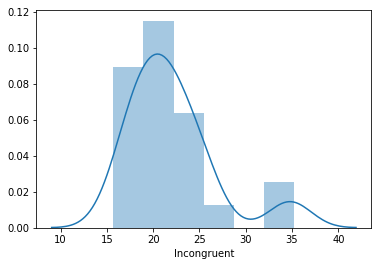

```python
# Build first visualization

sns.distplot(df['Incongruent'])
```

##### We can notice here that

- Upper end of our distribution is right skewed , which is not expect.
- Every thing else is normally as we expect.

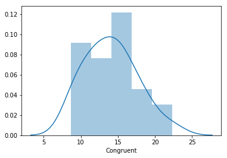

```python
# Build second visualization

sns.distplot(df['Congruent'])
```

We can notice here that data seems normally distributed.

(5) Now, perform the statistical test and report your results. What is your confidence level or Type I error associated with your test? What is your conclusion regarding the hypotheses you set up? Did the results match up with your expectations? **Hint:** Think about what is being measured on each individual, and what statistic best captures how an individual reacts in each environment.

```python
# Perform the statistical test here

import math
from scipy.stats import t
```

```python
# Check samples size

print(df['Congruent'].size)
print(df['Incongruent'].size)
```

```
24
24
```

```python
# significant value

t.ppf(.95, 23)
```

```
1.7138715277470473
```

```python
# Standard deviation for means differences

df['Difference'] = df['Congruent']-df['Incongruent']
df['Difference'].std(axis=0)
```

```
4.8648269103590556
```

```python
# our t-static

7.97/(4.8648 / math.sqrt(24))
```

```
8.025996238275749
```

#### which match our expectation .

(6) Optional: What do you think is responsible for the effects observed? Can you think of an alternative or similar task that would result in a similar effect? Some research about the problem will be helpful for thinking about these two questions!

I gess we can explain result using subconscious or habitual behaviour because the used of words repeatedly make it easily recognized in mind , so color and words match, and took little effort to say word/colour. However, when word and colour are mismatched, we have to think of it first then need to correct ourselves to say colour causing either errors or need more time to provide the correct response.